# 025-assignment

**Assignment: Predicting Apartment Prices in Mexico City 🇲🇽**

```python
import warnings

import wqet_grader

warnings.simplefilter(action="ignore", category=FutureWarning)
wqet_grader.init("Project 2 Assessment")
```

**Note:** In this project there are graded tasks in both the lesson notebooks and in this assignment. Together they total 24 points. The minimum score you need to move to the next project is 22 points. Once you get 22 points, you will be enrolled automatically in the next project, and this assignment will be closed. This means that you might not be able to complete the last two tasks in this notebook. If you get an error message saying that you've already passed the course, that's good news. You can stop this assignment and move onto the project 3.

In this assignment, you'll decide which libraries you need to complete the tasks. You can import them in the cell below. 👇

```python
# Import libraries here
import warnings
from glob import glob

import pandas as pd
import seaborn as sns
import wqet_grader
from category_encoders import OneHotEncoder
from IPython.display import VimeoVideo
from ipywidgets import Dropdown, FloatSlider, IntSlider, interact
from sklearn.impute import SimpleImputer
from sklearn.linear_model import LinearRegression, Ridge  # noqa F401
from sklearn.metrics import mean_absolute_error
from sklearn.pipeline import make_pipeline
from sklearn.utils.validation import check_is_fitted

import matplotlib.pyplot as plt
```

# Prepare Data

## Import

**Task 2.5.1:** (8 points) Write a `wrangle` function that takes the name of a CSV file as input and returns a DataFrame. The function should do the following steps:

1. Subset the data in the CSV file and return only apartments in Mexico City (`"Distrito Federal"`) that cost less than \$100,000.
2. Remove outliers by trimming the bottom and top 10\% of properties in terms of `"surface_covered_in_m2"`.
3. Create separate `"lat"` and `"lon"` columns.
4. Mexico City is divided into [16 boroughs](https://en.wikipedia.org/wiki/Boroughs_of_Mexico_City). Create a `"borough"` feature from the `"place_with_parent_names"` column.
5. Drop columns that are more than 50\% null values.
6. Drop columns containing low- or high-cardinality categorical values.
7. Drop any columns that would constitute leakage for the target `"price_aprox_usd"`.
8. Drop any columns that would create issues of multicollinearity.

**Tip:** Don't try to satisfy all the criteria in the first version of your `wrangle` function. Instead, work iteratively. Start with the first criteria, test it out with one of the Mexico CSV files in the `data/` directory, and submit it to the grader for feedback. Then add the next criteria.

```python
files = glob('./data/mexico-city-real-estate-[0-5].csv')
files
```

```
['./data/mexico-city-real-estate-5.csv',
 './data/mexico-city-real-estate-2.csv',
 './data/mexico-city-real-estate-1.csv',
 './data/mexico-city-real-estate-3.csv',
 './data/mexico-city-real-estate-4.csv']
```

```python
frame = []
for i in files:
    df = pd.read_csv(i)
    frame.append(df)
df = pd.concat([i for i in frame])
```

```python
df.info()
```

```
<class 'pandas.core.frame.DataFrame'>
Int64Index: 23140 entries, 0 to 4627
Data columns (total 16 columns):
 #   Column                      Non-Null Count  Dtype
---  ------                      --------------  -----
 0   operation                   23140 non-null  object
 1   property_type               23140 non-null  object
 2   place_with_parent_names     23140 non-null  object
 3   lat-lon                     20698 non-null  object
 4   price                       22745 non-null  float64
 5   currency                    22745 non-null  object
 6   price_aprox_local_currency  22745 non-null  float64
 7   price_aprox_usd             22745 non-null  float64
 8   surface_total_in_m2         8633 non-null   float64
 9   surface_covered_in_m2       22215 non-null  float64
 10  price_usd_per_m2            6012 non-null   float64
 11  price_per_m2                21320 non-null  float64
 12  floor                       1531 non-null   float64
 13  rooms                       621 non-null    float64
 14  expenses                    14 non-null     float64
 15  properati_url               23140 non-null  object
dtypes: float64(10), object(6)
memory usage: 3.0+ MB
```

```python
# Build your `wrangle` function
def wrangle(filepath):
    df = pd.read_csv(filepath)
    mask1 = (df['property_type'] == 'apartment')
    mask2 = (df['price_aprox_usd'] < 100000)
    mask3 = (df['place_with_parent_names'].str.contains('Distrito Federal'))


    df = df[mask1 & mask2 & mask3]

    low, high = df['surface_covered_in_m2'].quantile([0.1, 0.9])
    maskArea = df['surface_covered_in_m2'].between(low, high)
    df = df[maskArea]

    df[['lat', 'lon']] = df['lat-lon'].str.split(',', expand=True).astype(float)
    df = df.drop(columns='lat-lon')

    df['borough'] = df['place_with_parent_names'].str.split('|', expand=True)[1]
    df = df.drop(columns='place_with_parent_names')

    columns_na = [i for i in df.columns if df[i].isna().sum() > int(len(df)/2)]
    df = df.drop(columns = columns_na)

    list_card = ["operation", "property_type",  "currency", "properati_url"]
    df = df.drop(columns = list_card)

    #leakage
    highlow_cardinality = ['price', 'price_aprox_local_currency', 'price_per_m2']
    df = df.drop(columns = highlow_cardinality)



    return df
```

```python
files = glob('./data/mexico-city-real-estate-[0-5].csv')
files
```

```
['./data/mexico-city-real-estate-5.csv',
 './data/mexico-city-real-estate-2.csv',
 './data/mexico-city-real-estate-1.csv',
 './data/mexico-city-real-estate-3.csv',
 './data/mexico-city-real-estate-4.csv']
```

```python
# Use this cell to test your wrangle function and explore the data
frame = []
for i in files:
    df = wrangle(i)
    frame.append(df)
```

```python
df = pd.concat(frame)
df.info()
```

```
<class 'pandas.core.frame.DataFrame'>
Int64Index: 5473 entries, 1 to 4627
Data columns (total 5 columns):
 #   Column                 Non-Null Count  Dtype
---  ------                 --------------  -----
 0   price_aprox_usd        5473 non-null   float64
 1   surface_covered_in_m2  5473 non-null   float64
 2   lat                    5149 non-null   float64
 3   lon                    5149 non-null   float64
 4   borough                5473 non-null   object
dtypes: float64(4), object(1)
memory usage: 256.5+ KB
```

```python
# low or high cardinality
df.select_dtypes('object').nunique()
```

```
borough    15
dtype: int64
```

```python
list_card = ["operation", "property_type",  "currency", "properati_url"]
```

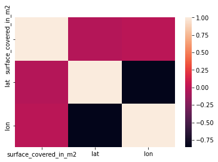

```python
corr = df.select_dtypes('number').drop(columns='price_aprox_usd').corr()
sns.heatmap(corr)
```

```python
highlow_cardinality = ['price', 'price_aprox_local_currency', 'price_usd_per_m2', 'price_per_m2']
```

```python
df['price_aprox_usd'].head()
```

```
1     82737.39
3     72197.60
4     44277.72
13    60589.45
18    47429.08
Name: price_aprox_usd, dtype: float64
```

```python
wqet_grader.grade(
    "Project 2 Assessment", "Task 25.1", wrangle("data/mexico-city-real-estate-1.csv")
)
```

Yup. You got it.

Score: 8

**Task 2.5.2:** Use glob to create the list `files`. It should contain the filenames of all the Mexico City real estate CSVs in the `./data` directory, except for `mexico-city-test-features.csv`.

```python
files = glob('./data/mexico-city-real-estate-[1-5].csv')
files
```

```
['./data/mexico-city-real-estate-5.csv',
 './data/mexico-city-real-estate-2.csv',
 './data/mexico-city-real-estate-1.csv',
 './data/mexico-city-real-estate-3.csv',
 './data/mexico-city-real-estate-4.csv']
```

```python
wqet_grader.grade("Project 2 Assessment", "Task 25.2", sorted(files))
```

Your submission doesn't match the expected result.

Score: 0

**Task 2.5.3:** Combine your `wrangle` function, a list comprehension, and `pd.concat` to create a DataFrame `df`. It should contain all the properties from the five CSVs in `files`.

```python
frame = []
for i in files:
    df = wrangle(i)
    frame.append(df)
```

```python
df = pd.concat(frame)
print(df.info())
df.head()
```

[output not shown]

[output not shown]

```python
df.shape
```

[output not shown]

```python
wqet_grader.grade("Project 2 Assessment", "Task 25.3", df)
```

You're making this look easy. 😉

Score: 1

## Explore

What does the distribution of price look like? Is the data normal, a little skewed, or very skewed?

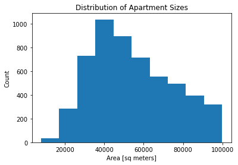

```python
# Plot distribution of price
plt.hist(df["price_aprox_usd"])
plt.xlabel("Area [sq meters]")
plt.ylabel('Count')
plt.title("Distribution of Apartment Sizes")

# Don't delete the code below 👇
plt.savefig("images/25-4.png", dpi=150)
```

```python
with open("images/25-4.png", "rb") as file:
    wqet_grader.grade("Project 2 Assessment", "Task 25.4", file)
```

Boom! You got it.

Score: 1

**Task 2.5.5:** Create a scatter plot that shows apartment price (`"price_aprox_usd"`) as a function of apartment size (`"surface_covered_in_m2"`). Be sure to label your axes `"Price [USD]"` and `"Area [sq meters]"`, respectively. Your plot should have the title `"Mexico City: Price vs. Area"`.

Do you see a relationship between price and area in the data? How is this similar to or different from the Buenos Aires dataset?

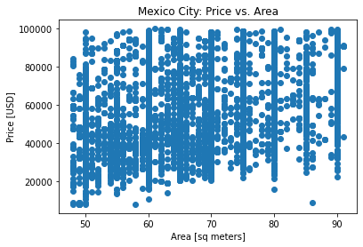

```python
# Plot price vs area
plt.scatter(x = df['surface_covered_in_m2'], y=df['price_aprox_usd'], )
plt.ylabel('Price [USD]')
plt.xlabel('Area [sq meters]')
plt.title('Mexico City: Price vs. Area')
# Don't delete the code below 👇
plt.savefig("images/25-5.png", dpi=150)
```

```python
with open("images/25-5.png", "rb") as file:
    wqet_grader.grade("Project 2 Assessment", "Task 25.5", file)
```

Correct.

Score: 1

**Task 2.5.6:** **(UNGRADED)** Create a Mapbox scatter plot that shows the location of the apartments in your dataset and represent their price using color.

What areas of the city seem to have higher real estate prices?

```python
# Plot Mapbox location and price
```

## Split

**Task 2.5.7:** Create your feature matrix `X_train` and target vector `y_train`. Your target is `"price_aprox_usd"`. Your features should be all the columns that remain in the DataFrame you cleaned above.

```python
df.columns
```

```
Index(['price_aprox_usd', 'surface_covered_in_m2', 'lat', 'lon', 'borough'], dtype='object')
```

```python
# Split data into feature matrix `X_train` and target vector `y_train`.
feature = 'price_aprox_usd'
X_train = df[['surface_covered_in_m2', 'lat', 'lon', 'borough']]
y_train = df[feature]
```

```python
wqet_grader.grade("Project 2 Assessment", "Task 25.7a", X_train)
```

Python master 😁

Score: 1

```python
wqet_grader.grade("Project 2 Assessment", "Task 25.7b", y_train)
```

Boom! You got it.

Score: 1

# Build Model

## Baseline

**Task 2.5.8:** Calculate the baseline mean absolute error for your model.

```python
y_mean = y_train.mean()
y_pred_baseline = [y_mean] * len(y_train)
baseline_mae = mean_absolute_error(y_train, y_pred_baseline)
print("Mean apt price:", y_mean)
print("Baseline MAE:", baseline_mae)
```

```
Mean apt price: 54246.5314982643
Baseline MAE: 17239.939475888303
```

```python
wqet_grader.grade("Project 2 Assessment", "Task 25.8", [baseline_mae])
```

Yes! Great problem solving.🥳

Score: 1

## Iterate

**Task 2.5.9:** Create a pipeline named `model` that contains all the transformers necessary for this dataset and one of the predictors you've used during this project. Then fit your model to the training data.

```python
model = make_pipeline(
    OneHotEncoder(use_cat_names = True),
    SimpleImputer(),
    Ridge()
)
model.fit(X_train, y_train)
```

```
Pipeline(steps=[('onehotencoder',
                 OneHotEncoder(cols=['borough'], use_cat_names=True)),
                ('simpleimputer', SimpleImputer()), ('ridge', Ridge())])
```

```python
wqet_grader.grade("Project 2 Assessment", "Task 25.9", model)
```

Wow, you're making great progress.

Score: 1

## Evaluate

**Task 2.5.10:** Read the CSV file `mexico-city-test-features.csv` into the DataFrame `X_test`.

```python
X_test = pd.read_csv('./data/mexico-city-test-features.csv')
print(X_test.info())
X_test.head()
```

```
<class 'pandas.core.frame.DataFrame'>
RangeIndex: 1041 entries, 0 to 1040
Data columns (total 4 columns):
 #   Column                 Non-Null Count  Dtype
---  ------                 --------------  -----
 0   surface_covered_in_m2  1041 non-null   float64
 1   lat                    986 non-null    float64
 2   lon                    986 non-null    float64
 3   borough                1041 non-null   object
dtypes: float64(3), object(1)
memory usage: 32.7+ KB
None
```

|  | surface_covered_in_m2 | lat | lon | borough |
| --- | --- | --- | --- | --- |
| 0 | 60.0 | 19.493185 | -99.205755 | Azcapotzalco |
| 1 | 55.0 | 19.307247 | -99.166700 | Coyoacán |
| 2 | 50.0 | 19.363469 | -99.010141 | Iztapalapa |
| 3 | 60.0 | 19.474655 | -99.189277 | Azcapotzalco |
| 4 | 74.0 | 19.394628 | -99.143842 | Benito Juárez |

```python
wqet_grader.grade("Project 2 Assessment", "Task 25.10", X_test)
```

That's the right answer. Keep it up!

Score: 1

**Task 2.5.11:** Use your model to generate a list of predictions for `X_test`. When you submit your predictions to the grader, it will calculate the mean absolute error for your model.

```python
y_test_pred = model.predict(X_test)
```

```python
wqet_grader.grade("Project 2 Assessment", "Task 25.11", list(y_test_pred))
```

The MAE for your model is: `14901.618`. Good work!

Score: 1

# Communicate Results

**Task 2.5.12:** Create a Series named `feat_imp`. The index should contain the names of all the features your model considers when making predictions; the values should be the coefficient values associated with each feature. The Series should be sorted ascending by absolute value.

```python
coefficients = model.named_steps['ridge'].coef_
```

```python
model.named_steps['onehotencoder'].get_feature_names()
```

```
['surface_covered_in_m2',
 'lat',
 'lon',
 'borough_Benito Juárez',
 'borough_Tlalpan',
 'borough_Iztapalapa',
 'borough_Gustavo A. Madero',
 'borough_Venustiano Carranza',
 'borough_Iztacalco',
 'borough_Coyoacán',
 'borough_Cuauhtémoc',
 'borough_Miguel Hidalgo',
 'borough_Azcapotzalco',
 'borough_Tláhuac',
 'borough_Álvaro Obregón',
 'borough_La Magdalena Contreras',
 'borough_Xochimilco',
 'borough_Cuajimalpa de Morelos']
```

```python
coefficients = model.named_steps['ridge'].coef_
features = ["surface_covered_in_m2",
 'lat',
 'lon',
 'borough_Benito Juárez',
 'borough_Tlalpan',
 'borough_Iztapalapa',
 'borough_Gustavo A. Madero',
 'borough_Venustiano Carranza',
 'borough_Iztacalco',
 'borough_Coyoacán',
 'borough_Cuauhtémoc',
 'borough_Miguel Hidalgo',
 'borough_Azcapotzalco',
 'borough_Tláhuac',
 'borough_Álvaro Obregón',
 'borough_La Magdalena Contreras',
 'borough_Xochimilco',
 'borough_Cuajimalpa de Morelos']
feat_imp = pd.Series(coefficients, index=features).sort_values(key=abs, ascending=True)
feat_imp
```

```
surface_covered_in_m2               291.654156
borough_Cuauhtémoc                 -350.531990
borough_Iztacalco                   405.403127
lat                                 478.901375
borough_Xochimilco                  929.857400
borough_Miguel Hidalgo             1977.314718
borough_Azcapotzalco               2459.288646
lon                               -2492.221814
borough_Álvaro Obregón             3275.121061
borough_Coyoacán                   3737.561001
borough_Venustiano Carranza       -5609.918629
borough_La Magdalena Contreras    -5925.666450
borough_Gustavo A. Madero         -6637.429757
borough_Cuajimalpa de Morelos      9157.269123
borough_Tlalpan                   10319.429804
borough_Iztapalapa               -13349.017448
borough_Benito Juárez             13778.188880
borough_Tláhuac                  -14166.869486
dtype: float64
```

```python
wqet_grader.grade("Project 2 Assessment", "Task 25.12", feat_imp)
```

Wow, you're making great progress.

Score: 1

**Task 2.5.13:** Create a horizontal bar chart that shows the **10 most influential** coefficients for your model. Be sure to label your x- and y-axis `"Importance [USD]"` and `"Feature"`, respectively, and give your chart the title `"Feature Importances for Apartment Price"`.

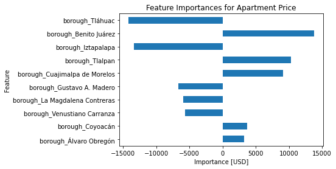

```python
# Create horizontal bar chart
feat_imp.tail(10).plot(kind='barh')
plt.xlabel("Importance [USD]")
plt.ylabel("Feature")
plt.title("Feature Importances for Apartment Price")




# Don't delete the code below 👇
plt.savefig("images/25-14.png", dpi=150)
```

```python
with open("images/25-14.png", "rb") as file:
    wqet_grader.grade("Project 2 Assessment", "Task 25.13", file)
```

[output not shown]

Copyright © 2022 WorldQuant University. This content is licensed solely for personal use. Redistribution or publication of this material is strictly prohibited.